# PEC1_INFERÈNCIA ESTADÍSTICA

Amelia Martínez Sequera

Abril 2020

## Ejercicio 1

1. Variable discreta X

```r
#A
0.1+0.25+0.3+0.15+0.1
```

```
## [1] 0.9
```

```r
#B
0.15+0.25+0.3+0.2+0.1
```

```
## [1] 1
```

Sólo B es posible, ya que la probabilidad del espacio muestral es 1, según uno de los axiomas de Kolmogorov. La suma de las probabilidades de los sucesos tiene que ser 1.

```r
#P(X=7)
a<- 0.2

#P(X>=5)= P(X=5)+P(X=7)+P(X=9)
b<- c(0.3,0.2,0.1)
sum(b) # 0.6
```

```
## [1] 0.6
```

```r
# P(5=<X<8) = P(X=5)+P(X=7)
d<- c(0.3,0.2)
sum(d) # 0.5
```

```
## [1] 0.5
```

```r
# P(X=7|X>=5) = P(X=7)/P(X>=5)
e<- intersect(a,b)/sum(b)
e # 0.3333333
```

```
## [1] 0.3333333
```

2. Variable continua Y.

La probabilidad acumulada máxima en una distribución continua es 1. Por lo que B no es posible.

P(Y=0)= 0, ya que si Y es continua la probabilidad de un punto de la recta es 0

P(Y<15)= 0.7

P(5<Y<15)= P(Y<15)-P(Y<5)= 0.7-0.4= 0.3

P(Y>5|Y<15)= P(5>Y>15)/P(Y<15)= 0.3/0.7= 0.4285714

```r
0.3/0.7
```

```
## [1] 0.4285714
```

## Ejercicio 2

A y B independientes

1. P(cura|A)=0.8

P(cura|B)=0.7

```r
0.8+0.7-(0.8*0.7)
```

```
## [1] 0.94
```

P(cura|A+B)= P(cura|A)+P(cura|B)-P(cura|A)P(cura|B) = 0.94

2. El resultado es el mismo, incluso si se aplican los tratamientos a la inversa:

0.8+0.7x0.2 = 0.94

0.7+0.3x0.8 = 0.94

3. 40% A

60% B

0.8x0.4+0.7x0.6= 0.74 = P(cura)

d)Teorema de Bayes: P(A|cura)= [P(cura|A)P(A)]/P(cura)= (0.8x0.4)/0.74= 0.43

```r
#Podríamos calcular la suma de la P(X=16),..,P(X=20):
x<-16:20
y<- dbinom(16:20,20,0.8)
data.frame("Prob"=y, row.names = x)
```

```
##          Prob
## 16 0.21819940
## 17 0.20536414
## 18 0.13690943
## 19 0.05764608
## 20 0.01152922
```

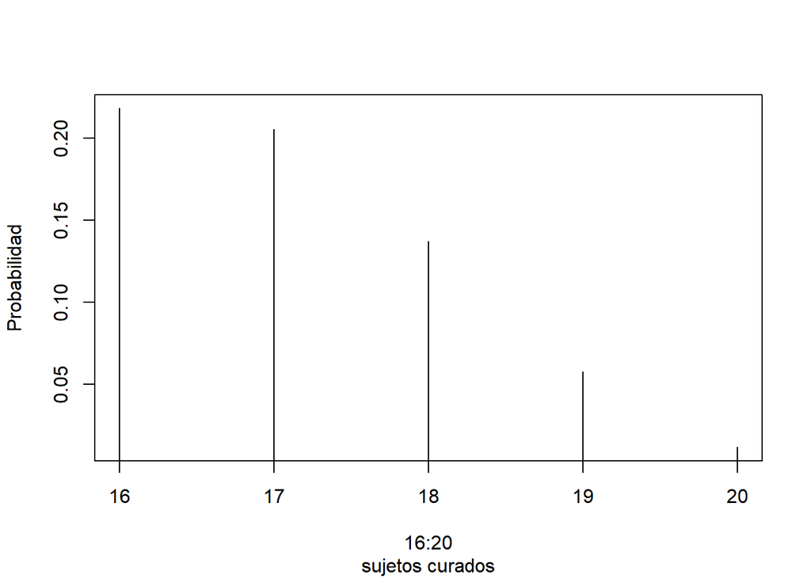

```r
plot(16:20, dbinom(16:20,20,0.8), type="h", ylab = "Probabilidad", sub="sujetos curados")
```

```r
#pero directamente podemos calcular la probabilidad de que se cureen 16 o más sujetos si #consideramos que equivale a 1 menos la probabilidad de que se curen 15 sujetos:
1-pbinom(15,20,0.8)
```

```
## [1] 0.6296483
```

g)Como es una muestra grande, por la teoría del límite central la media de una muestra aleatoria sigue una distribución normal centrada en la media de la población y con una desviación estándard(sd) igual a la sd de la población dividida por la raiz cuadrada del tamaño de la muestra. La desviación estándard es el error estándard.

```r
set.seed(2020)
muestra <- c(rbinom(1000,20,0.8))
media<- mean(muestra)
sd(muestra)
```

```
## [1] 1.807798
```

```r
alpha<- 0.05
cuantil<- qnorm(1-alpha/2)
lim_inferior<- media-cuantil*sd(muestra)/sqrt(1000)
lim_superior<- media+cuantil*sd(muestra)/sqrt(1000)
lim_superior
```

```
## [1] 16.16805
```

```r
lim_inferior
```

```
## [1] 15.94395
```

```r
t.test(muestra, conf.level = 0.95)
```

```
##
##  One Sample t-test
##
## data:  muestra
## t = 280.86, df = 999, p-value < 2.2e-16
## alternative hypothesis: true mean is not equal to 0
## 95 percent confidence interval:
##  15.94382 16.16818
## sample estimates:
## mean of x
##    16.056
```

Podemos calcular el intervalo de dos maneras, calculando primero la varianza (o desviación estándard), o con la t de Student si consideramos que la varianza es desconocida. El intervalo de confianza al 95% es (15.94382, 16.16818)

7. Consideramos Ho: media de la muestra = media esperada

```r
t.test(muestra, alternative ="two.sided", mu=16, conf.level = 0.95)
```

```
##
##  One Sample t-test
##
## data:  muestra
## t = 0.97958, df = 999, p-value = 0.3275
## alternative hypothesis: true mean is not equal to 16
## 95 percent confidence interval:
##  15.94382 16.16818
## sample estimates:
## mean of x
##    16.056
```

p-value>0.05 entonces no podemos rechazar la hipótesis nula. Podemos asumir que la media muestral es de 16. Esto ocurrirá para todos los intervalos donde el valor de significación sea inferior a 0.3275.

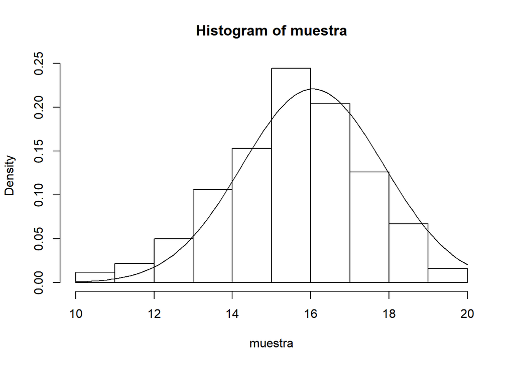

```r
media<- mean(muestra)
std<- sqrt(var(muestra))
hist(muestra, freq = F)
curve(dnorm(x, mean=media,sd=std), from= 10, to= 20, add = T)
```

10. Si la distribución de las medias de las muestras se acerca a una normal, si multiplicamos por 10 la muestra también lo harán la media y la desviación estándard en la misma proporción. La media pasará a estar en torno a 160, es decir habrá un cambio de posición sobre el eje x, y también de la dispersión.

## Ejercicio 3

1. N(160,31.4)

P(Xd<100)= F(100)

```r
pnorm(100, mean = 160, sd=31.4)
```

```
## [1] 0.02801334
```

el 2.8% se considerarían sanos siendo diabéticos.

2. N(80,10)

P(Xs>100)= 1-F(100)

```r
pnorm(100, mean=80, sd=10)
```

```
## [1] 0.9772499
```

```r
1-pnorm(100, mean = 80, sd=10)
```

```
## [1] 0.02275013
```

el 2.28% se clasificarian como diabéticos y en realidad estan sanos.

3. P(diabético|>100)= P(>100|diabético)P(diabético)/P(>100)=

= P(Xd>100)P(diabetico)/[P(Xd>100|diabetico)P(diabetico)+P(Xs>100|sano)P(sano)]=

```r
((1-0.02801334)*0.1)/(((1-0.02801334)*0.1)+(0.02275013*0.9))
```

```
## [1] 0.826001
```

el 82.6% de los individuos con un valor superior a 100 serán diabéticos.

```r
set.seed(2020)
rnorm(20, mean=160, sd=31.4)
```

```
##  [1] 171.83692 169.46862 125.52207 124.50525  72.18882 182.62601 189.48840
##  [8] 152.79754 215.23672 163.68532 133.21194 188.55074 197.56611 148.33227
## [15] 156.12963 216.52135 213.50547  64.58279  88.12619 161.83073
```

```r
mean(rnorm(20, mean=160, sd=31.4))
```

```
## [1] 174.2537
```

```r
alpha<- 0.05
media<- 174.2537
n<- 20
varianza <- (31.4)^2
cuantil<-qnorm(1-alpha/2)
lim_inf<-media-cuantil*sqrt(varianza)/sqrt(n)
lim_sup<-media+cuantil*sqrt(varianza)/sqrt(n)
lim_inf
```

```
## [1] 160.4923
```

```r
lim_sup
```

```
## [1] 188.0151
```

se tiene el 95% de confianza de que el intervalo [160.4923,188.0151] contenga el valor medio de la población.

```r
set.seed(2020)
mean(rnorm(350, mean=160, sd=31.4))
```

```
## [1] 158.9736
```

```r
alpha<- 0.05
media<- 158.9736
n<- 350
varianza <- (31.4)^2
cuantil<-qnorm(1-alpha/2)
lim_inf<-media-cuantil*sqrt(varianza)/sqrt(n)
lim_sup<-media+cuantil*sqrt(varianza)/sqrt(n)
lim_inf
```

```
## [1] 155.684
```

```r
lim_sup
```

```
## [1] 162.2632
```

se tiene el 95% de confianza de que el intervalo [155.684,162.2632] contenga el valor medio de la población.

Conclusión: al aumentar el tamaño de la muestra (n), la amplitud del intervalo disminuye. Según la Teoría del Límite Central: La media muestral de un número suficientemente largo de v.a. iid se aproxima a una distribución normal (más cuanto más crece el tamaño de la muestra) centrada en la media de la población y con una distribución estándard igual a la distribución estándard de la población dividida por la raíz cuadrada del tamaño de la muestra.